# Data Exploration and Analysis

## Feature Engineering and exploration in R

### Loading and inspecting dataset:

- Loading the Dataset

```r
library(dplyr)
library(tidyr)
library(tidyverse)
# Change the working directory as per the file location if required

dat_T1 <- read.csv("Studentmarks.csv", header = TRUE)
```

- Inspecting the Dataset

```r
dim(dat_T1)
```

```
## [1] 10  6
```

```r
#Checking for NAs
any(is.na(dat_T1))
```

```
## [1] FALSE
```

```r
#Checking for duplicated rows
any(duplicated(dat_T1))
```

```
## [1] FALSE
```

### Feature Engineering:

- Calculating age1 and binding it as a column to the dataframe. Using floor() as the age is supposed to be in years.

```r
# Used floor() as we need to round down to get age in absolute years
age1 <- floor(as.numeric(difftime(Sys.Date(), as.Date(dat_T1$dob, format = "%d/%m/%Y")))/365)

# Binding age1 as a column to the dataset
dat_T1 <- cbind(dat_T1, age1)
```

- Splitting the “dob” column into month and year columns

```r
# Converting the dob column to the date data type
dat_T1$dob <- as.Date(dat_T1$dob, format = "%d/%m/%Y")

# Extracting month and year column from dob
dat_T1 <- separate(dat_T1, dob, c("Year", "Month"))
```

- Calculating age2 and including it as a column in dataframe

```r
dat_T1$age2 <- as.numeric(format(Sys.Date(), "%Y"))-as.numeric(dat_T1$Year)
```

- Using gather() function to collect marks in a single column

```r
dat_T1.2 <- gather(dat_T1, "M_year", "Marks", 5:7)
```

- Plotting “Studentname” vs “Marks” using “Year” as color

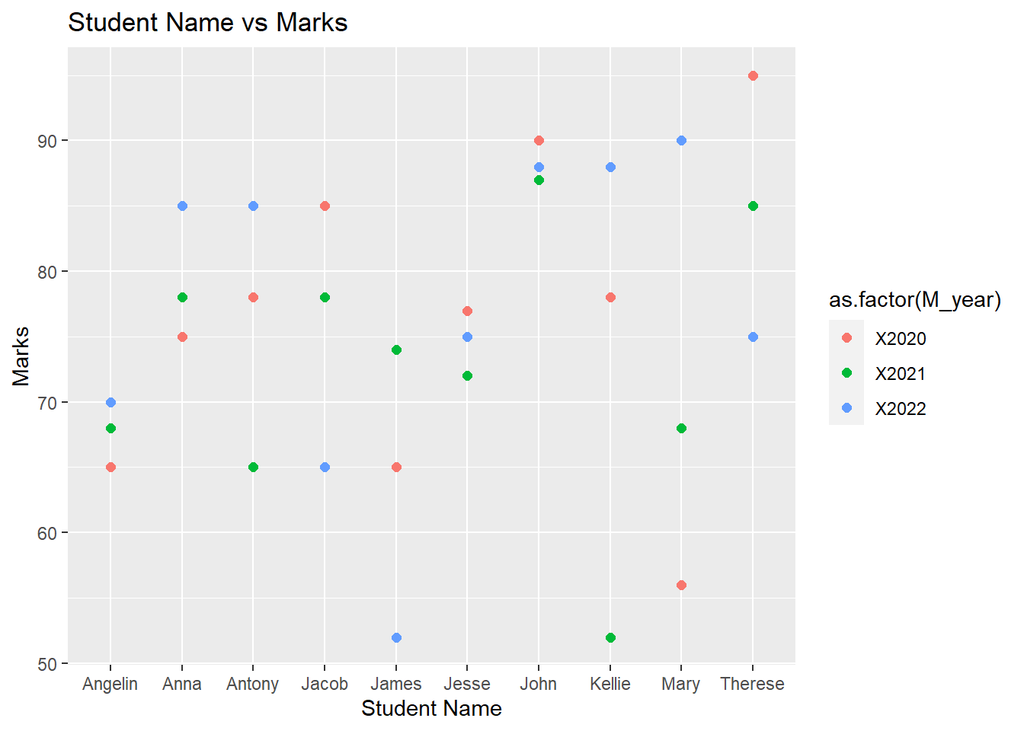

```r
library(ggplot2)
ggplot(dat_T1.2, aes(Studentname, Marks, color = as.factor(M_year))) +
  geom_point(size = 2) +
  labs(x = "Student Name", y = "Marks", title = "Student Name vs Marks")
```

Interpretation:

From the above chart, we can say that Anna, Kellie and Mary has shows significant improvement in their performance, whereas, Jacob and Therese has shown significant decline in their performance.

### Visualizing Marks for students above 200 mark criteria:

- Calculating Total Marks and filtering the data

```r
dat_T1.3 <- dat_T1 %>%
  mutate(TotalMarks = X2020 + X2021 + X2022) %>%
  filter(TotalMarks >= 200) %>%
  arrange(desc(TotalMarks))

nrow(dat_T1.3) #Only 1 student has been dropped for marks < 200
```

```
## [1] 9
```

- Plotting Bar Chart is descending order of marks

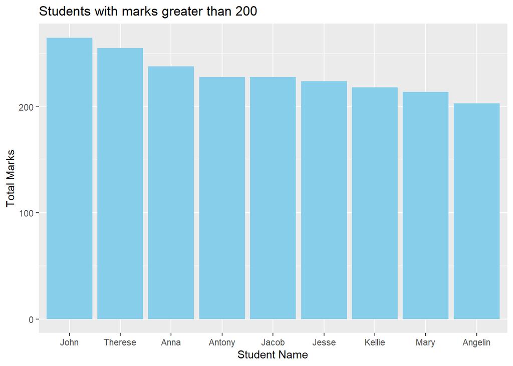

```r
#Load if not done before
#library(ggplot2)

ggplot(dat_T1.3, aes(x = reorder(Studentname, -TotalMarks), y = TotalMarks)) +
  geom_bar(stat = "identity", fill = "skyblue") +
  labs(x = "Student Name", y = "Total Marks",
       title = "Students with marks greater than 200")
```

## Data Augmentation and Correlation Analysis in R

### Loading and Preprocessing Data

- Loading the Dataset

```r
# Load if not done before
# library(dplyr)
# library(tidyr)
# library(tidyverse)

# Change the working directory as per the file location, if required

dat_T2 <- read.csv("Movies.csv", header = TRUE)
```

- Inspecting the Dataset

```r
dim(dat_T2)
```

```
## [1] 3891   26
```

```r
# Checking for duplicated records
any(duplicated(dat_T2)) #Returns TRUE
```

```
## [1] TRUE
```

```r
# Removing duplicated records
dat_T2 <- unique(dat_T2)
```

- Replacing all missing values (““) with NA so that is.na() function works on all the columns irrespective of the data type

```r
# Replacing "" with NA to make compatable with is.na() function
dat_T2 <- dat_T2 %>%
  mutate_all(~ifelse(. == "", NA, .))

# Checking NA count for each Column
sapply(dat_T2, function(x) sum(is.na(x)))
```

```
##                     Color                  Director                   Reviews
##                         2                         0                         1
##                  Duration   Director_facebook_likes    Actor_3_facebook_likes
##                         1                         0                        10
##              Actor_2_name    Actor_1_facebook_likes                     Gross
##                         5                         3                         0
##                     Genre              Actor_1_name                     Title
##                         0                         3                         0
##                     Votes Cast_total_facebook_likes              Actor_3_name
##                         0                         0                        10
##      Facenumber_in_poster             Plot_keywords           Movie_imdb_link
##                         6                        31                         0
##                  Language            Content_rating                    Budget
##                         0                        74                         0
##                      Year    Actor_2_facebook_likes                Imdb_score
##                         0                         5                         0
##              Aspect_ratio      Movie_facebook_likes
##                        74                         0
```

- Removing Columns: Each removal explained with reasoning
  - Removing “Movie_imdb_link” and “Plot_keywords” column

    –> “Movie_imbd_link” is unique for each movie, so not a good attribute to include.

    –> “Plot_keywords” is unique for each Movie, so should be excluded. However, a separate keyword analysis can be done, by separating each keyword for each movie to analyse which keyword attracts most audience. Moreover, it is quite redundant here, as Genre is decided based on the plot.

```r
dat_T2 <- subset(dat_T2, select = -c(Movie_imdb_link, Plot_keywords))
dim(dat_T2)
```

```
## [1] 3856   24
```

- - Removing “Language” Column

    –> The only language we have is “English”, so this column is unnecessary so we can remove it

```r
# Checking Language Column
levels(factor(dat_T2$Language))
```

```
## [1] "English"
```

```r
# As all the movies are in English, we can remove that column, as it wont be helpful in any analysis
dat_T2 <- subset(dat_T2, select = -c(Language))
dim(dat_T2)
```

```
## [1] 3856   23
```

- - Dealing with Actor info

    –> Actor_1 can be a part of another movie as well, but may be in the column of Actor_2 or Actor_3, so we need to combine them to make them more interpretable. So, extracting them in a separate dataframe to do a separate analysis later on if needed.

    –> However, Actor_facebook_likes are included as part of Cast_total_facebook_likes, so it can be removed from our comparative analysis

```r
# Extracting actor info in seperate dataframe
dat_actor <- subset(dat_T2, select = c(Title, Gross, Budget,
                                       Actor_1_name, Actor_1_facebook_likes,
                                       Actor_2_name, Actor_2_facebook_likes,
                                       Actor_3_name, Actor_3_facebook_likes))

# Removing it from our current dataframe
dat_T2 <- subset(dat_T2, select = -c(Actor_1_name, Actor_1_facebook_likes,
                                     Actor_2_name, Actor_2_facebook_likes,
                                     Actor_3_name, Actor_3_facebook_likes))
dim(dat_T2)
```

```
## [1] 3856   17
```

```r
# Rechecking NAs
sapply(dat_T2, function(x) sum(is.na(x)))
```

```
##                     Color                  Director                   Reviews
##                         2                         0                         1
##                  Duration   Director_facebook_likes                     Gross
##                         1                         0                         0
##                     Genre                     Title                     Votes
##                         0                         0                         0
## Cast_total_facebook_likes      Facenumber_in_poster            Content_rating
##                         0                         6                        74
##                    Budget                      Year                Imdb_score
##                         0                         0                         0
##              Aspect_ratio      Movie_facebook_likes
##                        74                         0
```

- - Removing the records with NAs in any of its columns

    –> All other attributes are important attribute from audience perspective, so we will eliminate all the rows where it has missing values.

```r
dat_T2 <- na.omit(dat_T2)
dim(dat_T2)
```

```
## [1] 3719   17
```

```r
# We have eliminated a total of 137 additional records with NAs from the dataset
```

### Relationship Analysis using Visualization:

- Calculating Profit and removing Gross and Budget Column

```r
# Calculating Profit
dat_T2$Profit <- dat_T2$Gross-dat_T2$Budget

# As now, Gross and Budget Columns are redundant, we can remove them
# Also the profit values are large, so rounding it to thousands to make it more readable
dat_T2 <- dat_T2 %>%
  mutate(Profit_Thousands = round(Profit/1000, 0)) %>%
  select(-c(Gross, Budget, Profit))
```

- Checking for Outliers: using boxplot

  –> Removed 5 outliers with least profit

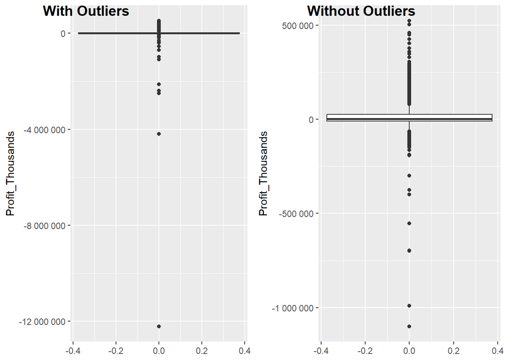

```r
# Load if not done before
# library(ggplot2)

# Plotting with Outliers
gbox_1 <- ggplot(dat_T2, aes(y=Profit_Thousands))+geom_boxplot() +
  scale_y_continuous(labels = scales::number_format(accuracy = 1))

# Removing last 5 outliers with big losses, to make the charts more readable
dat_T2_w <- dat_T2 %>% arrange(desc(Profit_Thousands))
dat_T2_w <- dat_T2_w[1:(nrow(dat_T2_w)-5),]

# Plotting without Outliers
gbox_2 <- ggplot(dat_T2_w, aes(y=Profit_Thousands))+geom_boxplot() +
  scale_y_continuous(labels = scales::number_format(accuracy = 1))

# Output
library(ggpubr)
ggarrange(gbox_1, gbox_2, labels = c("With Outliers", "Without Outliers"),
          ncol = 2, nrow = 1)
```

- Relationship analysis between “Profit_Thousands” and other variables

  Dividing this Analysis in two parts:

  –> Profit vs other Numerical Data-Types: Using Line plot

  –> Profit vs other Categorical Data-Types: Using Scatter plot
- Profit vs other Numerical Data-Types

  We will focus on “Imdb_score”, “Reviews”, “Votes”, “Movie_facebook_likes”

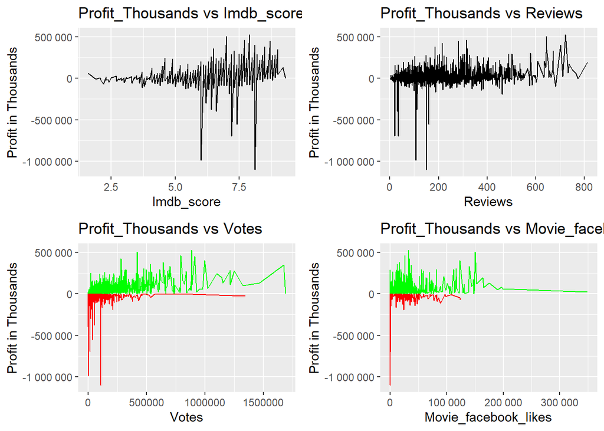

```r
# line plot
# We will be using the df without last 5 outliers as it is more visually interpretable

# Load if not done before
# library(ggplot2)

# "Profit_Thousands" vs "Imdb_score"
gline_1 <- ggplot(dat_T2_w, aes(x = Imdb_score, y = Profit_Thousands)) +
  geom_line() +
  scale_y_continuous(labels = scales::number_format(accuracy = 1)) +
  labs(x = "Imdb_score", y = "Profit in Thousands",
       title = "Profit_Thousands vs Imdb_score")

# "Profit_Thousands" vs "Reviews"
gline_2 <- ggplot(dat_T2_w, aes(x = Reviews, y = Profit_Thousands)) +
  geom_line() +
  scale_y_continuous(labels = scales::number_format(accuracy = 1)) +
  labs(x = "Reviews", y = "Profit in Thousands", title = "Profit_Thousands vs Reviews")

# "Profit_Thousands" vs "Votes"
gline_3 <- ggplot(dat_T2_w, aes(x = Votes, y = Profit_Thousands)) +
  geom_line(aes(color = ifelse(Profit_Thousands > 0, "Above 0", "Below 0"))) +
  scale_y_continuous(labels = scales::number_format(accuracy = 1)) +
  labs(x = "Votes", y = "Profit in Thousands", title = "Profit_Thousands vs Votes") +
  scale_color_manual(values = c("Above 0" = "green", "Below 0" = "red")) +
  guides(color = FALSE)
# "Profit_Thousands" vs "Movie_facebook_likes"
gline_4 <- ggplot(dat_T2_w, aes(x = Movie_facebook_likes, y = Profit_Thousands)) +
  geom_line(aes(color = ifelse(Profit_Thousands > 0, "Above 0", "Below 0"))) +
  scale_y_continuous(labels = scales::number_format(accuracy = 1)) +
  scale_x_continuous(labels = scales::number_format(accuracy = 1)) +
  labs(x = "Movie_facebook_likes", y = "Profit in Thousands",
       title = "Profit_Thousands vs Movie_facebook_likes") +
  scale_color_manual(values = c("Above 0" = "green", "Below 0" = "red")) +
  guides(color = FALSE)

# Output
# Load if not done before
# library(ggpubr)
ggarrange(gline_1, gline_2, gline_3, gline_4,
          ncol = 2, nrow = 2)
```

- Interpretation:

  –> It is clear from the line charts that Imdb score is not having much impact on the Profits, as even for the movies with high imdb score, the profits fluctuate a lot.

  –> For Reviews, there is more fluctuation in profits, where the reviews are below 200. Due to lack of data, it is very hard to say why profits show such a trend for Reviews.

We will focus on “Genre”, “Content_rating”, “Facenumber_in_poster” and “Aspect_ratio”

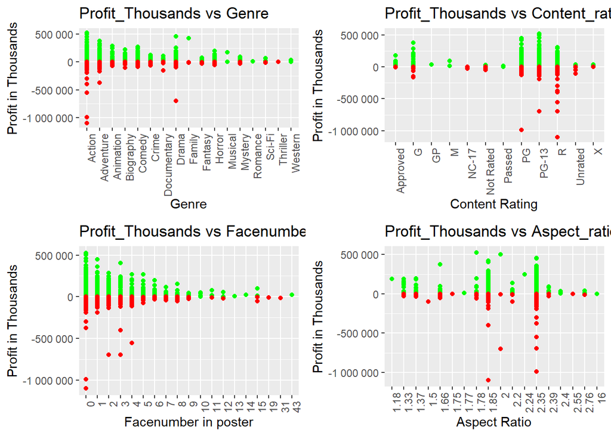

```r
# scatter plot
# We will be using the df without last 5 outliers as it is more visually interpretable

# Load if not done before
# library(ggplot2)

# "Profit_Thousands" vs "Genre"
gsp_1 <- ggplot(dat_T2_w, aes(x = factor(Genre), y = Profit_Thousands)) +
  geom_point(aes(color = ifelse(Profit_Thousands > 0, "Above 0", "Below 0"))) +
  scale_y_continuous(labels = scales::number_format(accuracy = 1)) +
  labs(x = "Genre", y = "Profit in Thousands",
       title = "Profit_Thousands vs Genre") +
  scale_color_manual(values = c("Above 0" = "green", "Below 0" = "red")) +
  guides(color = FALSE) +
  theme(axis.text.x = element_text(angle = 90, hjust = 1))

# "Profit_Thousands" vs "Content_rating"
gsp_2 <- ggplot(dat_T2_w, aes(x = factor(Content_rating), y = Profit_Thousands)) +
  geom_point(aes(color = ifelse(Profit_Thousands > 0, "Above 0", "Below 0"))) +
  scale_y_continuous(labels = scales::number_format(accuracy = 1)) +
  labs(x = "Content Rating", y = "Profit in Thousands",
       title = "Profit_Thousands vs Content_rating") +
  scale_color_manual(values = c("Above 0" = "green", "Below 0" = "red")) +
  guides(color = FALSE) +
  theme(axis.text.x = element_text(angle = 90, hjust = 1))

# "Profit_Thousands" vs "Facenumber_in_poster"
gsp_3 <- ggplot(dat_T2_w, aes(x = factor(Facenumber_in_poster), y = Profit_Thousands)) +
  geom_point(aes(color = ifelse(Profit_Thousands > 0, "Above 0", "Below 0"))) +
  scale_y_continuous(labels = scales::number_format(accuracy = 1)) +
  labs(x = "Facenumber in poster", y = "Profit in Thousands",
       title = "Profit_Thousands vs Facenumber_in_poster") +
  scale_color_manual(values = c("Above 0" = "green", "Below 0" = "red")) +
  guides(color = FALSE) +
  theme(axis.text.x = element_text(angle = 90, hjust = 1))

# "Profit_Thousands" vs "Aspect_ratio"
gsp_4 <- ggplot(dat_T2_w, aes(x = factor(Aspect_ratio), y = Profit_Thousands)) +
  geom_point(aes(color = ifelse(Profit_Thousands > 0, "Above 0", "Below 0"))) +
  scale_y_continuous(labels = scales::number_format(accuracy = 1)) +
  labs(x = "Aspect Ratio", y = "Profit in Thousands",
       title = "Profit_Thousands vs Aspect_ratio") +
  scale_color_manual(values = c("Above 0" = "green", "Below 0" = "red")) +
  guides(color = FALSE) +
  theme(axis.text.x = element_text(angle = 90, hjust = 1))

# Output
# Load if not done before
# library(ggpubr)
ggarrange(gsp_1, gsp_2, gsp_3, gsp_4, ncol = 2, nrow = 2)
```

- Interpretation:

  –> For Genre, Profits are more fluctating for Action, Adventure and Drama in comparison to other Genres

  –> For Content Rating, “R” rated movies show the most fluction in Profits. Moreover, “GP”, “M” and “Passed” rated movies has shown profits only so far and “MC-17” rated movies has shown losses only so far.

  –> For Facenumber_in_Poster and Aspect_ratio, the visualization is not very meaningful. The only thing, which is visible for facenumber is that, the profits fluctuate less as we have more facenumbers in the poster.

### Correlation Analysis:

- Calculating Correlation between variables: Using Spearman’s rank correlation as it can deal with outliers and skewed distributions

```r
# Using the dataset without excluding outliers
# As Spearman's Correlation can only deal with ordinal, interval or ratio, so removing all the columns not required
dat_T2_c <- dat_T2 %>%
  select(-c(Color, Director, Genre, Title, Content_rating, Aspect_ratio))

# Using Spearman's rank correlation
cor_T2 <- cor(dat_T2_c,  use = "everything", method = c("spearman"))
# Rounding to 4 decimals to make it more readable
round(cor_T2, 4)
```

```
##                           Reviews Duration Director_facebook_likes   Votes
## Reviews                    1.0000   0.2456                  0.1738  0.7536
## Duration                   0.2456   1.0000                  0.1843  0.3407
## Director_facebook_likes    0.1738   0.1843                  1.0000  0.2128
## Votes                      0.7536   0.3407                  0.2128  1.0000
## Cast_total_facebook_likes  0.3140   0.2500                  0.2142  0.4172
## Facenumber_in_poster      -0.0918   0.0464                  0.0002 -0.0632
## Year                       0.5397  -0.0277                  0.0287  0.1242
## Imdb_score                 0.3474   0.3912                  0.1364  0.4747
## Movie_facebook_likes       0.3767   0.1290                  0.0562  0.2691
## Profit_Thousands           0.1617   0.0104                  0.0501  0.3849
##                           Cast_total_facebook_likes Facenumber_in_poster
## Reviews                                      0.3140              -0.0918
## Duration                                     0.2500               0.0464
## Director_facebook_likes                      0.2142               0.0002
## Votes                                        0.4172              -0.0632
## Cast_total_facebook_likes                    1.0000               0.0946
## Facenumber_in_poster                         0.0946               1.0000
## Year                                         0.1358               0.0581
## Imdb_score                                   0.1256              -0.0863
## Movie_facebook_likes                         0.1542              -0.0054
## Profit_Thousands                             0.0800              -0.0450
##                              Year Imdb_score Movie_facebook_likes
## Reviews                    0.5397     0.3474               0.3767
## Duration                  -0.0277     0.3912               0.1290
## Director_facebook_likes    0.0287     0.1364               0.0562
## Votes                      0.1242     0.4747               0.2691
## Cast_total_facebook_likes  0.1358     0.1256               0.1542
## Facenumber_in_poster       0.0581    -0.0863              -0.0054
## Year                       1.0000    -0.0750               0.3453
## Imdb_score                -0.0750     1.0000               0.1827
## Movie_facebook_likes       0.3453     0.1827               1.0000
## Profit_Thousands          -0.0943     0.2465               0.0515
##                           Profit_Thousands
## Reviews                             0.1617
## Duration                            0.0104
## Director_facebook_likes             0.0501
## Votes                               0.3849
## Cast_total_facebook_likes           0.0800
## Facenumber_in_poster               -0.0450
## Year                               -0.0943
## Imdb_score                          0.2465
## Movie_facebook_likes                0.0515
## Profit_Thousands                    1.0000
```

- Plotting Correlation Matrix

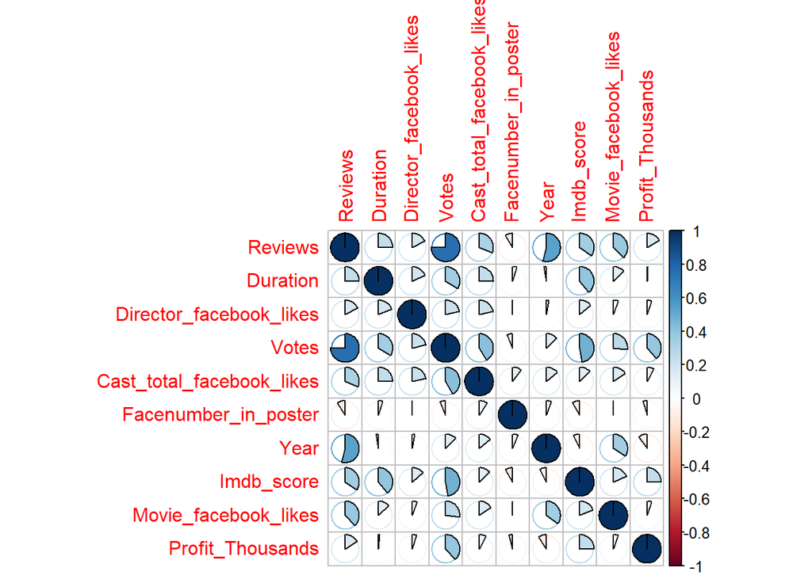

```r
library(corrplot)
# Plotting Correlation Matrix using "pie" method
corrplot(cor_T2, method = "pie")
```

- Calculating Strong and Weak Correlations

  –> Used pie method to visualize correlation matrix, to easily detect the strong and weak correlations.

  –> Any value of correlation above 0.5 or below -0.5 are considered as strong and weak otherwise

  –> From the above plot, it is clear that we have only two strong correlated variables, i.e. “Reviews and Votes” & “Reviews and Year”

  –> For Weak Correlation, we need to look at the values closest to zero, visually the weakest two are “Facenumber_in_poster and Director_Facebook_likes” & “Facenumber_in_poster and Movie_facebook_likes”

```r
# Reconfirming strong correlations
cor_st_1 <- cor_T2["Reviews", "Votes"]
cor_st_1
```

```
## [1] 0.753583
```

```r
cor_st_2 <- cor_T2["Reviews", "Year"]
cor_st_2
```

```
## [1] 0.5397092
```

```r
# both have value above 0.5, so Strong Correlation

# Reconfirming weak correlations
cor_wk_1 <- cor_T2["Facenumber_in_poster", "Director_facebook_likes"]
cor_wk_1
```

```
## [1] 0.0002258789
```

```r
cor_wk_2 <- cor_T2["Facenumber_in_poster", "Movie_facebook_likes"]
cor_wk_2
```

```
## [1] -0.005418264
```

```r
# both have value close to 0, so Weak Correlation
```

- Visualising Strong and Weak Correlations

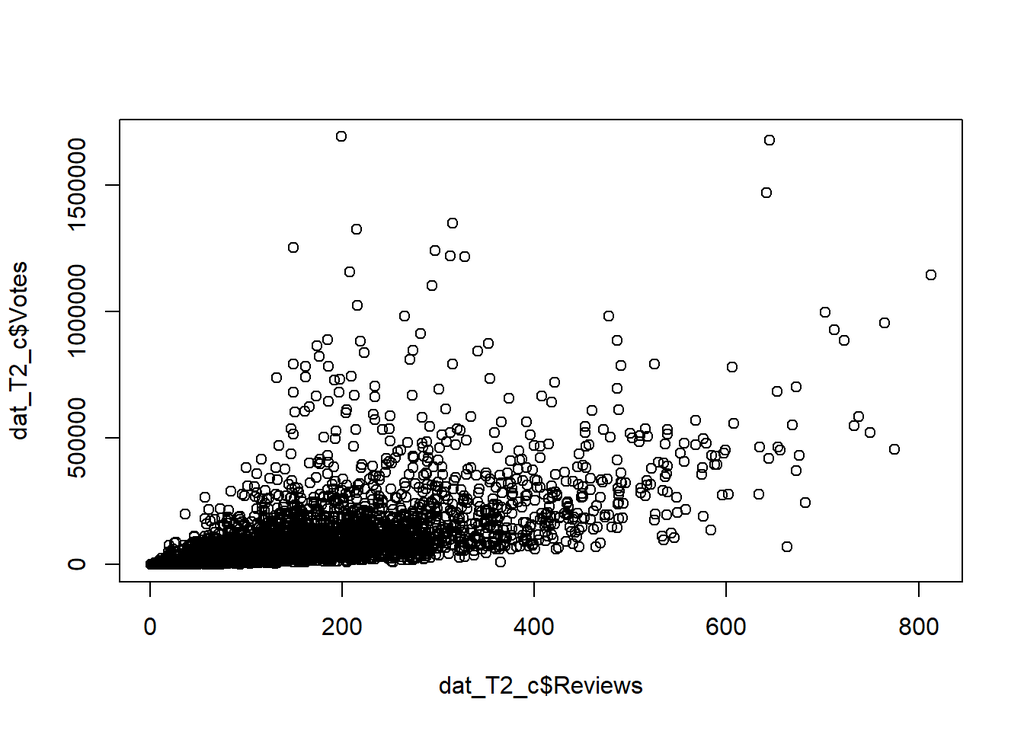

```r
# Strong Correlation Reviews and Votes
plot(x = dat_T2_c$Reviews, y = dat_T2_c$Votes)
```

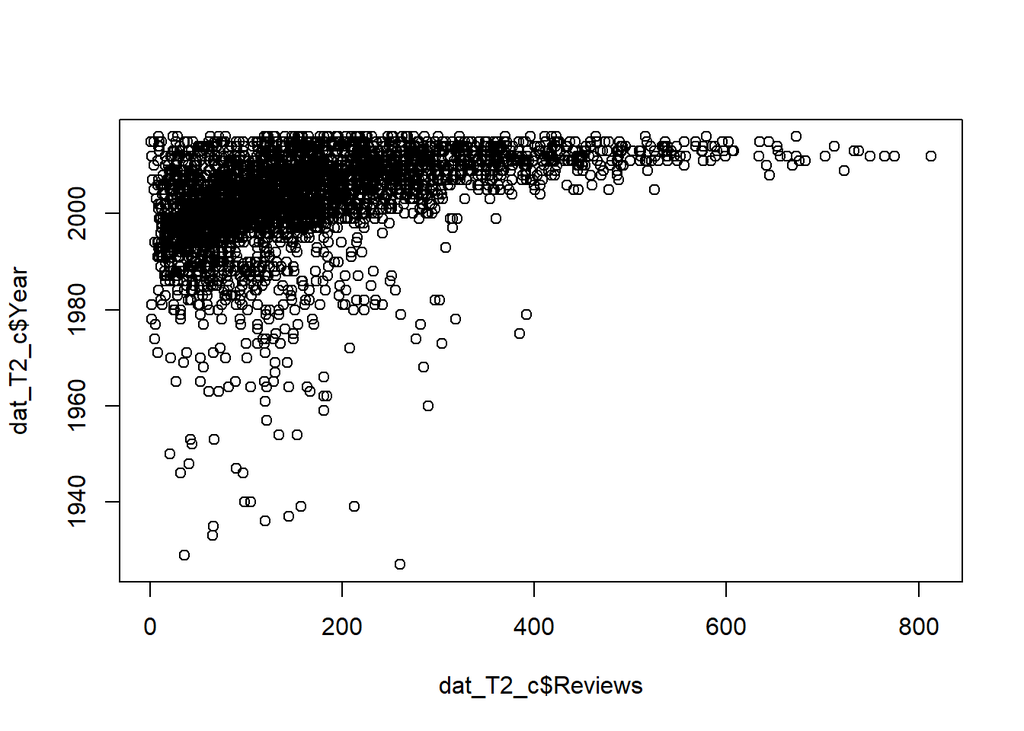

```r
# Strong Correlation Reviews and Year
plot(x = dat_T2_c$Reviews, y = dat_T2_c$Year)
```

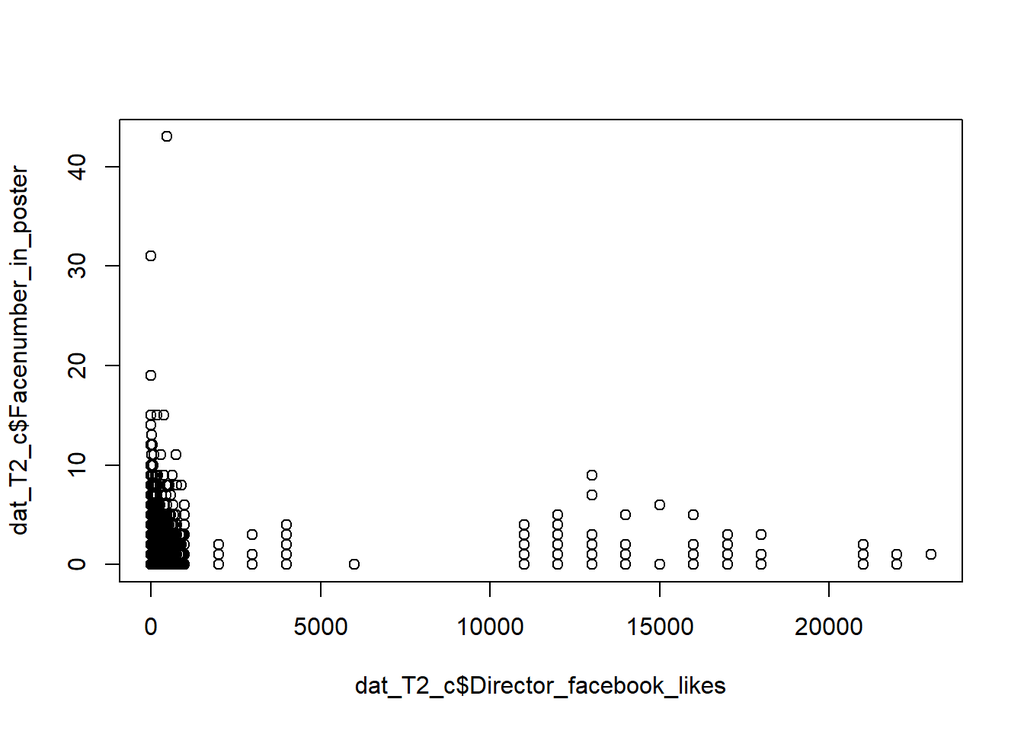

```r
# Weak Correlation Facenumber_in_poster and Director_Facebook_likes
plot(x = dat_T2_c$Director_facebook_likes, y = dat_T2_c$Facenumber_in_poster)
```

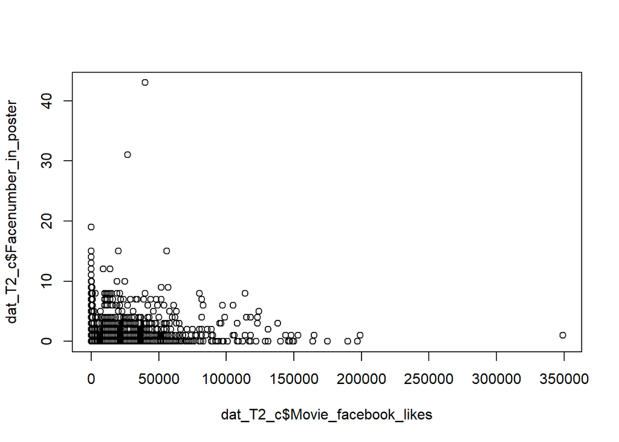

```r
# Weak Correlation Facenumber_in_poster and Movie_Facebook_likes
plot(x = dat_T2_c$Movie_facebook_likes, y = dat_T2_c$Facenumber_in_poster)
```

The above plots for strong correlation show some directional plot, with outliers, whereas, no such pattern is visible for weak correlations